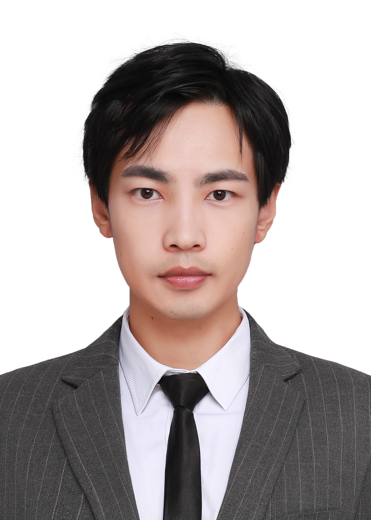

Xinqi Zhou

Primary Investigator

### Current Members

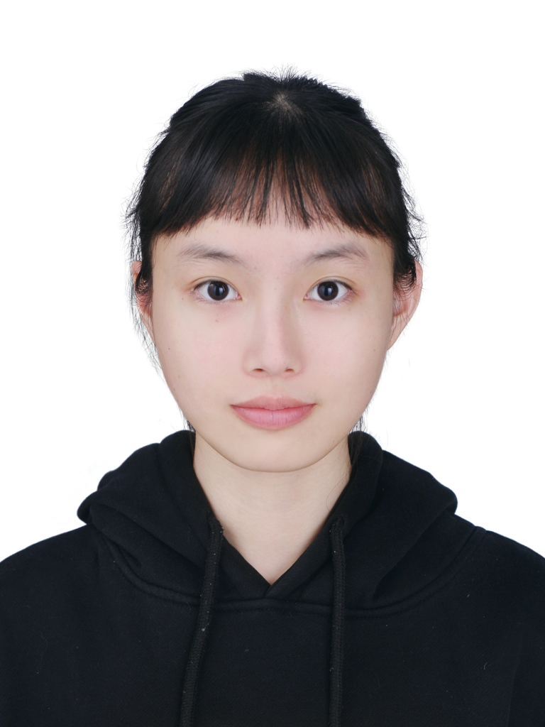

Tingran Chen

Graduate Student (2024)

I’m a feminist, queer. My research interests are decison-making, emotion, and reward. My hobbies are running, biking, dancing, music, and puzzle game.

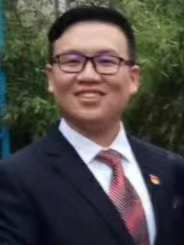

Jingrong Tian

Graduate Student (2024)

Research Interests: Cyber psychology and internet violence

Love succulent, aquarium, coffee, and reading

[figure not shown]

Yuping Xiong

Graduate Student (2025)

Research Interests: AI interaction, decision-making

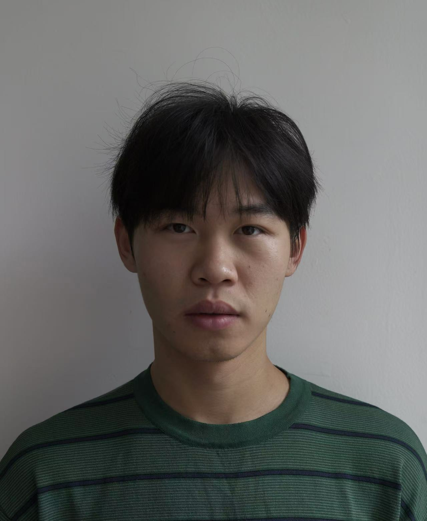

Mingrui Zhang

Graduate Student (2025)

Research Interests: decision-making

My hobbies are music, photography, movie.

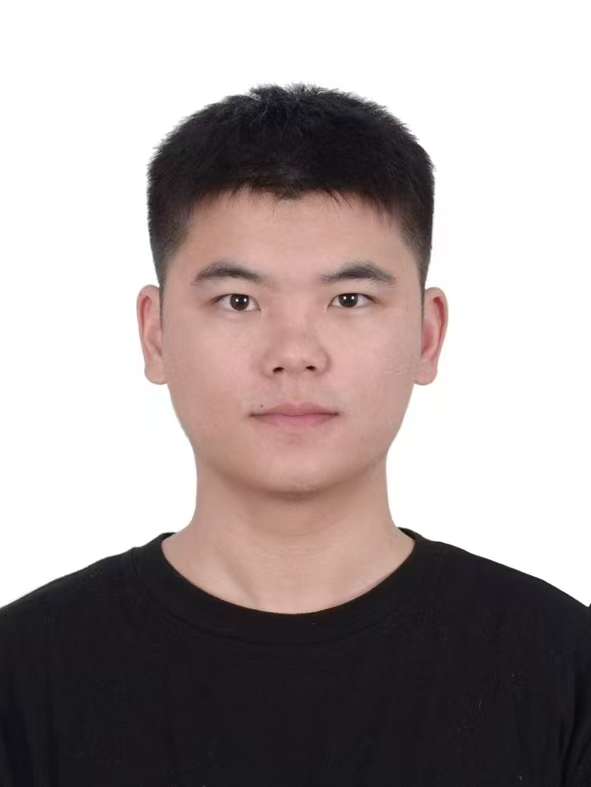

Zhiqi Kang

Graduate Student (2026)

Research Interests: human-AI interaction

Hobbies: cooking

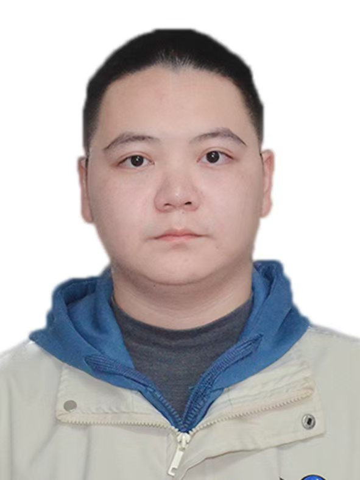

Jiajun Ren

Graduate Student (2026)

Research Interests: human-AI interaction, decision-making

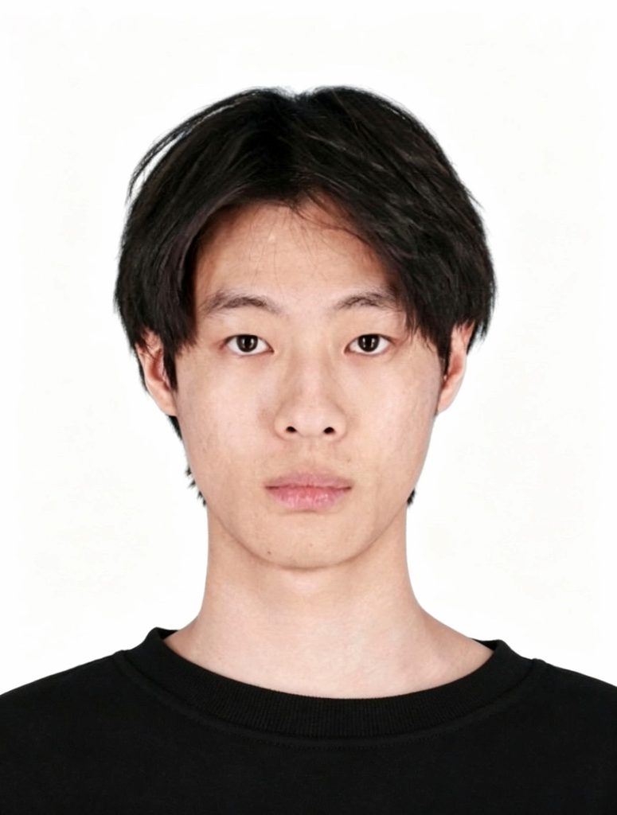

Zhenhao Shou

Graduate Student (2026)

Research Interests: Human-AI interaction and decision-making

My hobbies are hiking and climbing the moutains.

[figure not shown]

Mengze Sun

Graduate Student (2026)

Research Interests: Human computer interaction and social decision-making, mainly including the psychological and neural mechanisms in the process of human AI collaboration

Personal hobbies: reading, handmade crafts

### Lab Alumni

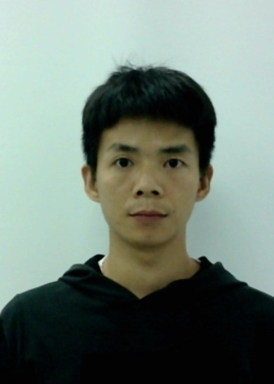

Changchun Liu

Graduate Student (2022)

Research Interests: The influence of emotion on decision-making behavior under uncertain conditions

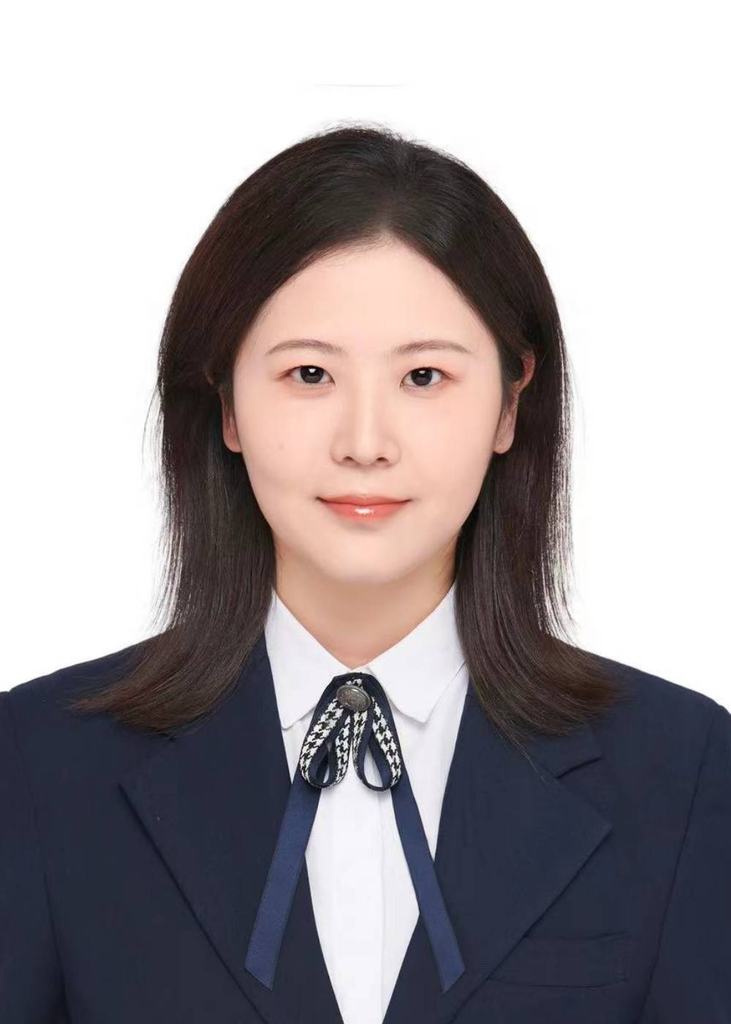

Yuchun Li

Graduate Student (2023)

Research Interests: Social decision-making and social competition

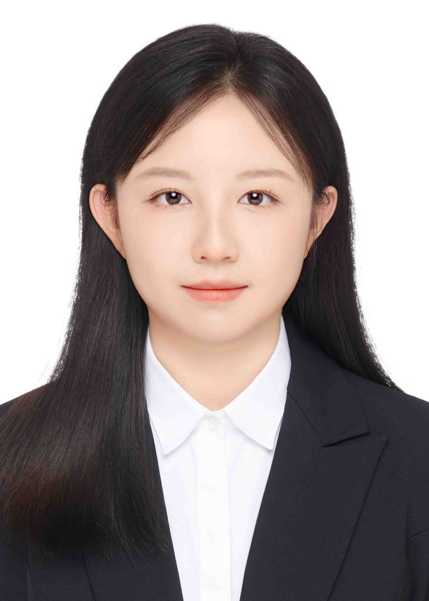

Liuqing Jiang

Graduate Student (2023)

Research Interests: Internet addiction, motivation, and effort